# Acoustic enrichment and mass larval release amplify coral settlement success

### Rugosity

Surface Area Ratio (SAR) by treatment and site. Bars show the mean SAR for each treatment (control, acoustic, larval, larval+acoustic) within each site (S1–S6). SAR is a dimensionless rugosity metric computed as the ratio of 3D surface area to the corresponding planar (2D) area for each plot/patch-reef tile; values >1 indicate increasing surface complexity relative to a flat surface. For each site, SAR was calculated per unit (e.g., tile/plot) from the underlying orthomosaic derived Digital Elevation Model (DEM), then aggregated as the mean within treatment × site for plotting.

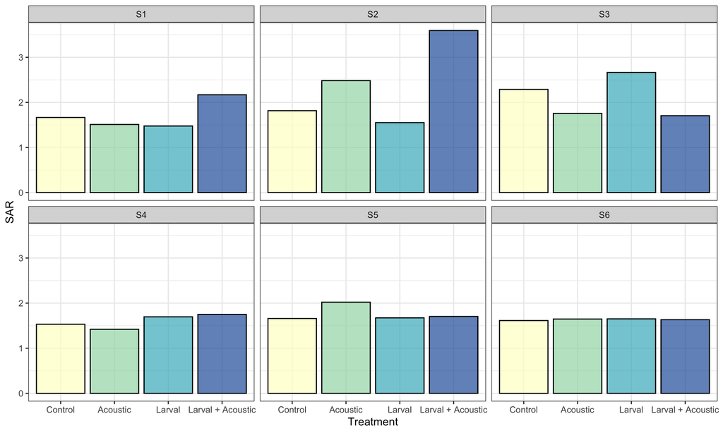

```r
metrics <- c("mean","sd","min","max","range","iqr","vrm","sar")

rugosity_site_means <- rugosity %>%
  group_by(site) %>%
  summarise(
    across(all_of(metrics), ~ mean(.x, na.rm = TRUE)),
    n_tiles = n(),
    .groups = "drop"
  ) %>%
  arrange(site)


rugosity %>%
  mutate(
    site = factor(site),
    treatment = factor(treatment, levels = c("control","acoustic","larval","larvalacoustic"))
  ) %>%
  mutate(treatment = fct_recode(treatment, Control = "control", Acoustic = "acoustic", Larval = "larval", "Larval + Acoustic" = "larvalacoustic")) |>
  ggplot(aes(x = treatment, y = sar, group = site)) +
  geom_col(aes(fill = treatment), , colour="black", alpha = 0.7, show.legend=FALSE) +
  scale_fill_manual(values = scales::brewer_pal(palette = "YlGnBu")(4)[1:4]) +
#  geom_line(aes(color = site), linewidth = 0.5, alpha = 0.7) +
  facet_wrap(~ site, ncol = 3) +
  theme_bw() +
  labs(x = "Treatment", y = "SAR")
```

```r
#
# corr_mat <- rugosity %>%
#   select(mean, sd, min, max, range, iqr, vrm, sar) %>%
#   cor(use = "complete.obs", method = "pearson")
#
# ggcorrplot::ggcorrplot(corr_mat, lab = TRUE, type = "lower", show.legend = TRUE) +
#   theme_bw() + ylab("") + xlab("")
```